# 🚀 Telecom Customer Churn Prediction Project 📊

## 🎯 Amaç ve Hedef:

Bu projenin temel amacı, telekomünikasyon müşterilerinin ayrılma durumlarını tahmin etmek ve bu tahminleri kullanarak müşteri kaybını azaltmaya yönelik stratejiler geliştirmektir. Projemizin ana hedefleri şunlardır:

1. Müşteri kaybını anlamak ve müşteri ayrılmasını etkileyen faktörleri belirlemek.
2. Müşteri kaybını tahmin etmek için doğru ve güvenilir bir model oluşturmak.
3. Müşteri kaybını azaltmaya yönelik stratejiler ve öneriler geliştirmek.

## 📋 Veri Seti Tanımı:

Bu projede kullanacağımız veri seti, telekomünikasyon müşterileriyle ilgili çeşitli öznitelikleri içerir. Veri setimizde toplamda 7043 satır ve 21 sütun bulunmaktadır. İşte veri setimizde bulunan sütunların detaylı bir açıklaması:

1. **customerID**: Müşteri kimliği
2. **gender**: Müşterinin cinsiyeti (Erkek veya Kadın)
3. **SeniorCitizen**: Müşterinin yaşlı bir vatandaş olup olmadığı (1: Evet, 0: Hayır)
4. **Partner**: Müşterinin bir partneri olup olmadığı (Evet, Hayır)
5. **Dependents**: Müşterinin bakmakla yükümlü olduğu kişilerin olup olmadığı (Evet, Hayır)
6. **tenure**: Müşterinin şirketle geçirdiği ay sayısı
7. **PhoneService**: Müşterinin telefon hizmeti olup olmadığı (Evet, Hayır)
8. **MultipleLines**: Müşterinin birden fazla hatta sahip olup olmadığı (Evet, Hayır, Telefon hizmeti yok)
9. **InternetService**: Müşterinin internet hizmet sağlayıcısı (DSL, Fiber optik, Yok)
10. **OnlineSecurity**: Müşterinin çevrimiçi güvenliğe sahip olup olmadığı (Evet, Hayır, İnternet hizmeti yok)
11. **Churn**: Müşterinin ayrılma durumu (Hedef değişkenimiz)

Bu veri setindeki sütunlar, müşteri kaybını tahmin etmek için kullanılacak olan temel öznitelikleri temsil eder. "Churn" sütunu hedef değişkenimizdir ve projemizin odak noktasıdır.

## 📊 Veri Keşfi ve Ön İşleme:

Bu aşamada, veri setimizi daha ayrıntılı bir şekilde keşfedecek ve ön işleme adımlarını gerçekleştireceğiz. İşte yapacaklarımız:

1. **Veri Seti İncelemesi**: Veri setimizi yükleyeceğiz ve yapısal bir analiz yapacağız.
2. **Eksik Veri Kontrolü**: Eksik veri olup olmadığını kontrol edeceğiz ve gerektiğinde bunları işleyeceğiz.
3. **Veri Türleri ve Dağılımları**: Sütunların veri tiplerini inceleyecek ve dağılımlarını görselleştireceğiz.
4. **Aykırı Değerlerin İncelenmesi**: Aykırı değerleri tespit edecek ve bunlarla başa çıkmak için stratejiler belirleyeceğiz.
5. **Özellik Mühendisliği**: Mevcut özelliklerden yeni özellikler türetecek ve model performansını artırmak için veri setimizi zenginleştireceğiz.

## 📈 Veri Analizi ve Keşif (EDA):

Bu aşamada, veri setimizi daha derinlemesine analiz edecek ve müşteri kaybıyla ilişkili önemli örüntüleri ve ilişkileri keşfedeceğiz. İşte yapacaklarımız:

1. **Değişkenler Arası İlişkiler**: Değişkenler arasındaki ilişkileri görselleştirecek ve analiz edeceğiz.
2. **Churn Dağılımı**: Müşteri kaybının dağılımını inceleyecek ve müşteri kaybıyla ilişkili faktörleri belirleyeceğiz.
3. **Demografik Analiz**: Cinsiyet, yaş ve diğer demografik faktörlerle müşteri kaybı arasındaki ilişkiyi araştıracağız.
4. **Hizmet Kullanımı Analizi**: Müşterilerin hizmet kullanım alışkanlıklarını inceleyecek ve müşteri kaybıyla ilişkilendireceğiz.
5. **Müşteri Memnuniyeti ve Sadakati**: Müşteri memnuniyeti ve sadakatiyle müşteri kaybı arasındaki ilişkiyi değerlendireceğiz.

## 🛠️ Model Geliştirme ve Eğitimi:

Bu aşamada, modelimizi oluşturacak, eğitecek ve değerlendireceğiz. İşte yapacaklarımız:

## 📉 Sonuçların Değerlendirilmesi:

Modelimizin performansını ve elde ettiğimiz sonuçları değerlendireceğiz. İşte yapacaklarımız:

1. **Performans Metrikleri**: Modelin performansını değerlendirmek için uygun metrikleri kullanacağız. Doğruluk, hassasiyet, geri çağırma ve F1 puanı gibi metrikleri göz önünde bulunduracağız.
2. **Sonuçlar**: Modelimizin başarı oranını, güçlü ve zayıf yönlerini ve iyileştirme alanlarını analiz edeceğiz.
3. **Öneriler**: Modelin başarısını artırmak için önerilerde bulunacak ve gelecekteki adımları tartışacağız.

```python
# Veri analizi ve manipülasyonu için
import pandas as pd
import numpy as np

# Veri görselleştirme için
import matplotlib.pyplot as plt
import seaborn as sns

# Veri setini yüklemek için
import os

# Önişleme ve modelleme için
from sklearn.model_selection import train_test_split, GridSearchCV
from sklearn.preprocessing import StandardScaler
from sklearn.metrics import classification_report, confusion_matrix, roc_curve, roc_auc_score, accuracy_score
from sklearn.svm import SVC
from sklearn.datasets import load_iris
from sklearn.feature_selection import RFE
from sklearn.metrics import f1_score

# İstatiksel Analizler için
from scipy.stats import zscore
from sklearn.decomposition import PCA
from sklearn.cluster import KMeans

# İlerlemiş görselleştirme araçları
import plotly.express as px
import plotly.graph_objects as go

# Derin Öğrenme Modeli için
import tensorflow as tf
from tensorflow.keras.models import Sequential
from tensorflow.keras.layers import Dense, Dropout
from sklearn.preprocessing import OneHotEncoder

# Sınıflandırma algoritmaları
from sklearn.ensemble import RandomForestClassifier

# Uyarıları kapatma
import warnings
warnings.filterwarnings('ignore')
```

```python
# Veri setini oku
df = pd.read_csv("../data/WA_Fn-UseC_-Telco-Customer-Churn.csv")

# Veri setinin ilk 5 satırını göster
df.head()
```

|  | customerID | gender | SeniorCitizen | Partner | Dependents | tenure | PhoneService | MultipleLines | InternetService | OnlineSecurity | ... | DeviceProtection | TechSupport | StreamingTV | StreamingMovies | Contract | PaperlessBilling | PaymentMethod | MonthlyCharges | TotalCharges | Churn |
| --- | --- | --- | --- | --- | --- | --- | --- | --- | --- | --- | --- | --- | --- | --- | --- | --- | --- | --- | --- | --- | --- |
| 0 | 7590-VHVEG | Female | 0 | Yes | No | 1 | No | No phone service | DSL | No | ... | No | No | No | No | Month-to-month | Yes | Electronic check | 29.85 | 29.85 | No |
| 1 | 5575-GNVDE | Male | 0 | No | No | 34 | Yes | No | DSL | Yes | ... | Yes | No | No | No | One year | No | Mailed check | 56.95 | 1889.5 | No |
| 2 | 3668-QPYBK | Male | 0 | No | No | 2 | Yes | No | DSL | Yes | ... | No | No | No | No | Month-to-month | Yes | Mailed check | 53.85 | 108.15 | Yes |
| 3 | 7795-CFOCW | Male | 0 | No | No | 45 | No | No phone service | DSL | Yes | ... | Yes | Yes | No | No | One year | No | Bank transfer (automatic) | 42.30 | 1840.75 | No |
| 4 | 9237-HQITU | Female | 0 | No | No | 2 | Yes | No | Fiber optic | No | ... | No | No | No | No | Month-to-month | Yes | Electronic check | 70.70 | 151.65 | Yes |

5 rows × 21 columns

Burada "data/WA_Fn-UseC_-Telco-Customer-Churn.csv" dosya yolunu, veri setinin bulunduğu konuma uygun olarak değiştirmeniz gerekebilir. Ardından, head() yöntemini kullanarak veri setinin ilk 5 satırını görüntüleyebilirsiniz.

```python
# Veri setinin boyutunu kontrol et
print("Veri Seti Boyutu:", df.shape)

# Temel istatistiksel bilgileri görüntüle
print("\nTemel İstatistiksel Bilgiler:")
print(df.describe())
```

```
Veri Seti Boyutu: (7043, 21)

Temel İstatistiksel Bilgiler:
       SeniorCitizen       tenure  MonthlyCharges
count    7043.000000  7043.000000     7043.000000
mean        0.162147    32.371149       64.761692
std         0.368612    24.559481       30.090047
min         0.000000     0.000000       18.250000
25%         0.000000     9.000000       35.500000
50%         0.000000    29.000000       70.350000
75%         0.000000    55.000000       89.850000
max         1.000000    72.000000      118.750000
```

Bu kod, veri setinin boyutunu kontrol eder ve temel istatistiksel bilgileri (örneğin, ortalama, standart sapma, minimum, maksimum vb.) görüntüler. Bu bilgiler, veri setindeki sayısal sütunların dağılımı hakkında bir fikir verir.

```python
# Eksik değerleri kontrol et
print("\nEksik Değerler:")
print(df.isnull().sum())

# Her sütundaki benzersiz değerleri incele
print("\nHer Sütundaki Benzersiz Değerler:")
for column in df.columns:
    print(f"{column}: {df[column].nunique()} benzersiz değer")
```

```
Eksik Değerler:
customerID          0
gender              0
SeniorCitizen       0
Partner             0
Dependents          0
tenure              0
PhoneService        0
MultipleLines       0
InternetService     0
OnlineSecurity      0
OnlineBackup        0
DeviceProtection    0
TechSupport         0
StreamingTV         0
StreamingMovies     0
Contract            0
PaperlessBilling    0
PaymentMethod       0
MonthlyCharges      0
TotalCharges        0
Churn               0
dtype: int64

Her Sütundaki Benzersiz Değerler:
customerID: 7043 benzersiz değer
gender: 2 benzersiz değer
SeniorCitizen: 2 benzersiz değer
Partner: 2 benzersiz değer
Dependents: 2 benzersiz değer
tenure: 73 benzersiz değer
PhoneService: 2 benzersiz değer
MultipleLines: 3 benzersiz değer
InternetService: 3 benzersiz değer
OnlineSecurity: 3 benzersiz değer
OnlineBackup: 3 benzersiz değer
DeviceProtection: 3 benzersiz değer
TechSupport: 3 benzersiz değer
StreamingTV: 3 benzersiz değer
StreamingMovies: 3 benzersiz değer
Contract: 3 benzersiz değer
PaperlessBilling: 2 benzersiz değer
PaymentMethod: 4 benzersiz değer
MonthlyCharges: 1585 benzersiz değer
TotalCharges: 6531 benzersiz değer
Churn: 2 benzersiz değer
```

Bu kod, veri setindeki eksik değerleri kontrol eder ve her sütundaki benzersiz değerlerin sayısını görüntüler. Bu bilgiler, eksik veri olup olmadığını ve her sütunun çeşitliliği hakkında fikir verir.

```python
# Veri setindeki sütun türlerini belirle
numeric_columns = df.select_dtypes(include=np.number).columns.tolist()
categorical_columns = df.select_dtypes(exclude=np.number).columns.tolist()

# Kategorik sütunlardaki benzersiz değerleri incele
print("\nKategorik Sütunlardaki Benzersiz Değerler:")
for column in categorical_columns:
    print(f"{column}: {df[column].unique()}")
```

```
Kategorik Sütunlardaki Benzersiz Değerler:
customerID: ['7590-VHVEG' '5575-GNVDE' '3668-QPYBK' ... '4801-JZAZL' '8361-LTMKD'
 '3186-AJIEK']
gender: ['Female' 'Male']
Partner: ['Yes' 'No']
Dependents: ['No' 'Yes']
PhoneService: ['No' 'Yes']
MultipleLines: ['No phone service' 'No' 'Yes']
InternetService: ['DSL' 'Fiber optic' 'No']
OnlineSecurity: ['No' 'Yes' 'No internet service']
OnlineBackup: ['Yes' 'No' 'No internet service']
DeviceProtection: ['No' 'Yes' 'No internet service']
TechSupport: ['No' 'Yes' 'No internet service']
StreamingTV: ['No' 'Yes' 'No internet service']
StreamingMovies: ['No' 'Yes' 'No internet service']
Contract: ['Month-to-month' 'One year' 'Two year']
PaperlessBilling: ['Yes' 'No']
PaymentMethod: ['Electronic check' 'Mailed check' 'Bank transfer (automatic)'
 'Credit card (automatic)']
TotalCharges: ['29.85' '1889.5' '108.15' ... '346.45' '306.6' '6844.5']
Churn: ['No' 'Yes']
```

Bu kod, veri setindeki kategorik ve sayısal sütunları belirler ve kategorik sütunlardaki benzersiz değerleri görüntüler. Bu bilgiler, kategorik sütunlardaki farklı kategorilere sahip olup olmadığını ve bunların nasıl kodlanabileceğini belirlemede yardımcı olur.

```
Hedef Değişken Dağılımı:
Churn
No     5174
Yes    1869
Name: count, dtype: int64
```

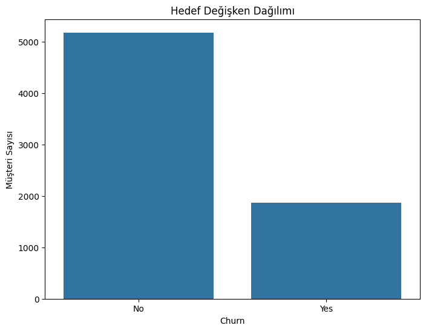

```python
# Hedef değişkenin dağılımını kontrol et
print("\nHedef Değişken Dağılımı:")
print(df['Churn'].value_counts())

# Hedef değişkenin dağılımını görselleştir
plt.figure(figsize=(8, 6))
sns.countplot(data=df, x='Churn')
plt.title('Hedef Değişken Dağılımı')
plt.xlabel('Churn')
plt.ylabel('Müşteri Sayısı')
plt.show()
```

Bu kod, hedef değişkenin (Churn) dağılımını görüntüler. Ayrıca, bir çubuk grafiği aracılığıyla hedef değişkenin dağılımını görselleştirir. Bu, müşteri ayrılma durumunun dengesizliğini ve veri setinde potansiyel bir sınıf dengesizliği olup olmadığını anlamak için önemlidir.

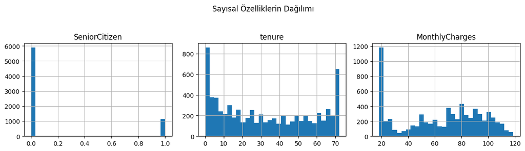

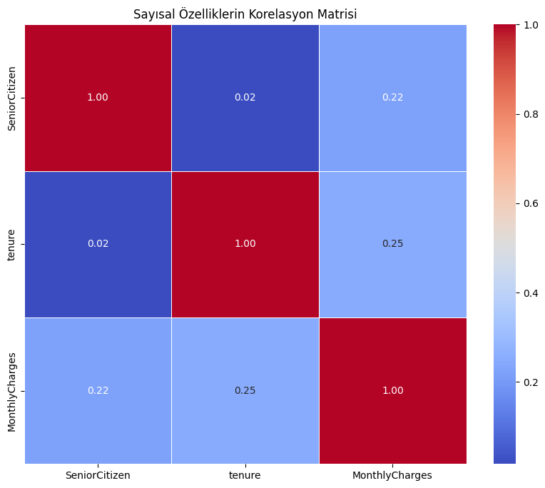

```python
# Sayısal özelliklerin dağılımını görselleştir
plt.figure(figsize=(12, 8))
df[numeric_columns].hist(bins=30, figsize=(12, 8), layout=(3, 3))
plt.suptitle('Sayısal Özelliklerin Dağılımı', y=1.02)
plt.tight_layout()
plt.show()

# Korelasyon matrisini hesapla
correlation_matrix = df[numeric_columns].corr()

# Korelasyon matrisini görselleştir
plt.figure(figsize=(10, 8))
sns.heatmap(correlation_matrix, annot=True, cmap='coolwarm', fmt=".2f", linewidths=0.5)
plt.title('Sayısal Özelliklerin Korelasyon Matrisi')
plt.show()
```

Bu kod, sayısal özelliklerin dağılımını histogramlar aracılığıyla görselleştirir ve sayısal özellikler arasındaki korelasyonu bir ısı haritasıyla gösterir. Bu, özellikler arasındaki ilişkileri anlamak için önemlidir.

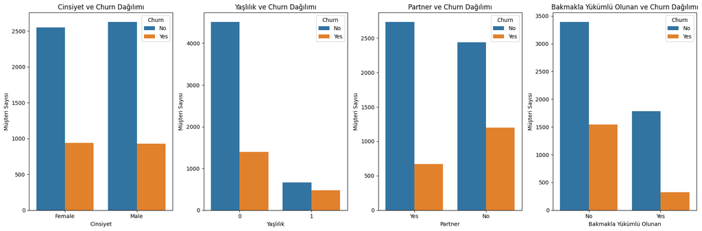

```python
# Demografik özelliklerin Churn ile ilişkisini görselleştir
plt.figure(figsize=(18, 6))

plt.subplot(1, 4, 1)
sns.countplot(data=df, x='gender', hue='Churn')
plt.title('Cinsiyet ve Churn Dağılımı')
plt.xlabel('Cinsiyet')
plt.ylabel('Müşteri Sayısı')

plt.subplot(1, 4, 2)
sns.countplot(data=df, x='SeniorCitizen', hue='Churn')
plt.title('Yaşlılık ve Churn Dağılımı')
plt.xlabel('Yaşlılık')
plt.ylabel('Müşteri Sayısı')

plt.subplot(1, 4, 3)
sns.countplot(data=df, x='Partner', hue='Churn')
plt.title('Partner ve Churn Dağılımı')
plt.xlabel('Partner')
plt.ylabel('Müşteri Sayısı')

plt.subplot(1, 4, 4)
sns.countplot(data=df, x='Dependents', hue='Churn')
plt.title('Bakmakla Yükümlü Olunan ve Churn Dağılımı')
plt.xlabel('Bakmakla Yükümlü Olunan')
plt.ylabel('Müşteri Sayısı')

plt.tight_layout()
plt.show()
```

Bu kod, cinsiyet, yaşlılık durumu, partner ve bakmakla yükümlü olunan kişi sayısı gibi demografik özelliklerin müşteri ayrılma durumuyla ilişkisini görselleştirir. Bu, demografik özelliklerin müşteri churn üzerindeki etkisini anlamak için önemlidir.

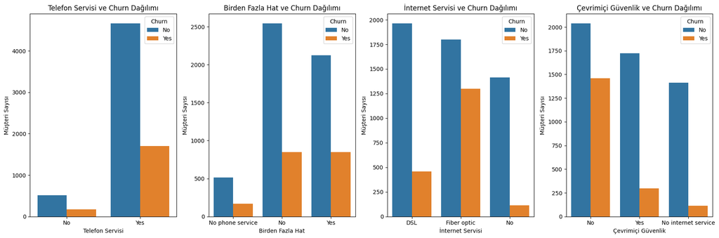

```python
# Hizmet kullanımının Churn ile ilişkisini görselleştir
plt.figure(figsize=(18, 6))

plt.subplot(1, 4, 1)
sns.countplot(data=df, x='PhoneService', hue='Churn')
plt.title('Telefon Servisi ve Churn Dağılımı')
plt.xlabel('Telefon Servisi')
plt.ylabel('Müşteri Sayısı')

plt.subplot(1, 4, 2)
sns.countplot(data=df, x='MultipleLines', hue='Churn')
plt.title('Birden Fazla Hat ve Churn Dağılımı')
plt.xlabel('Birden Fazla Hat')
plt.ylabel('Müşteri Sayısı')

plt.subplot(1, 4, 3)
sns.countplot(data=df, x='InternetService', hue='Churn')
plt.title('İnternet Servisi ve Churn Dağılımı')
plt.xlabel('İnternet Servisi')
plt.ylabel('Müşteri Sayısı')

plt.subplot(1, 4, 4)
sns.countplot(data=df, x='OnlineSecurity', hue='Churn')
plt.title('Çevrimiçi Güvenlik ve Churn Dağılımı')
plt.xlabel('Çevrimiçi Güvenlik')
plt.ylabel('Müşteri Sayısı')

plt.tight_layout()
plt.show()
```

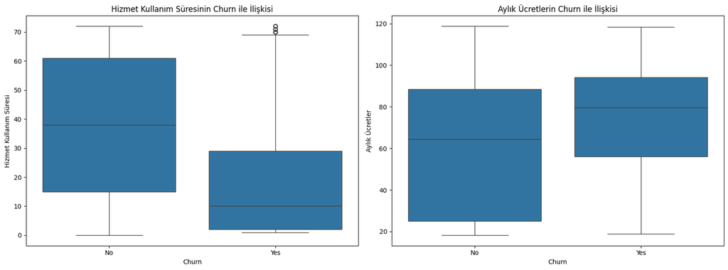

```python
# Hizmet kullanım süresinin ve aylık ücretlerin Churn ile ilişkisini görselleştir
plt.figure(figsize=(16, 6))

plt.subplot(1, 2, 1)
sns.boxplot(data=df, x='Churn', y='tenure')
plt.title('Hizmet Kullanım Süresinin Churn ile İlişkisi')
plt.xlabel('Churn')
plt.ylabel('Hizmet Kullanım Süresi')

plt.subplot(1, 2, 2)
sns.boxplot(data=df, x='Churn', y='MonthlyCharges')
plt.title('Aylık Ücretlerin Churn ile İlişkisi')
plt.xlabel('Churn')
plt.ylabel('Aylık Ücretler')

plt.tight_layout()
plt.show()
```

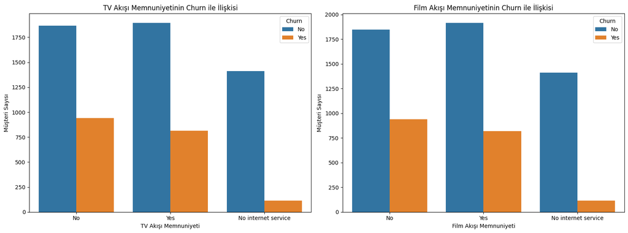

```python
# Hizmet memnuniyetinin Churn ile ilişkisini görselleştir
plt.figure(figsize=(16, 6))

plt.subplot(1, 2, 1)
sns.countplot(data=df, x='StreamingTV', hue='Churn')
plt.title('TV Akışı Memnuniyetinin Churn ile İlişkisi')
plt.xlabel('TV Akışı Memnuniyeti')
plt.ylabel('Müşteri Sayısı')

plt.subplot(1, 2, 2)
sns.countplot(data=df, x='StreamingMovies', hue='Churn')
plt.title('Film Akışı Memnuniyetinin Churn ile İlişkisi')
plt.xlabel('Film Akışı Memnuniyeti')
plt.ylabel('Müşteri Sayısı')

plt.tight_layout()
plt.show()
```

Bu kod, müşterilerin TV akışı ve film akışı hizmetlerine yönelik memnuniyet düzeylerini Churn ile ilişkilendirir ve bu ilişkinin bar grafikleri aracılığıyla görselleştirir. Bu, hizmet memnuniyetinin müşteri ayrılma durumu üzerindeki etkisini anlamak için önemlidir.

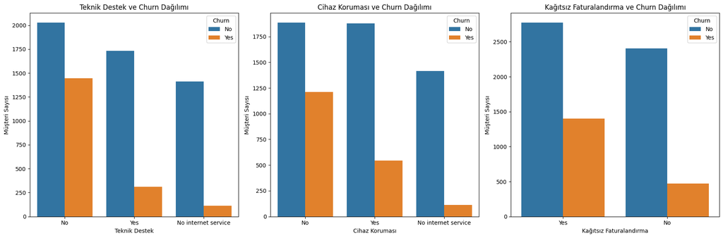

```python
# Ek hizmet özelliklerinin Churn ile ilişkisini görselleştir
plt.figure(figsize=(18, 6))

plt.subplot(1, 3, 1)
sns.countplot(data=df, x='TechSupport', hue='Churn')
plt.title('Teknik Destek ve Churn Dağılımı')
plt.xlabel('Teknik Destek')
plt.ylabel('Müşteri Sayısı')

plt.subplot(1, 3, 2)
sns.countplot(data=df, x='DeviceProtection', hue='Churn')
plt.title('Cihaz Koruması ve Churn Dağılımı')
plt.xlabel('Cihaz Koruması')
plt.ylabel('Müşteri Sayısı')

plt.subplot(1, 3, 3)
sns.countplot(data=df, x='PaperlessBilling', hue='Churn')
plt.title('Kağıtsız Faturalandırma ve Churn Dağılımı')
plt.xlabel('Kağıtsız Faturalandırma')
plt.ylabel('Müşteri Sayısı')

plt.tight_layout()
plt.show()
```

Bu kod, müşterilerin teknik destek, cihaz koruması ve kağıtsız faturalandırma gibi ek hizmet özelliklerini müşteri ayrılma durumuyla ilişkilendirir ve bu ilişkinin bar grafikleri aracılığıyla görselleştirir. Bu, ek hizmet özelliklerinin müşteri ayrılma durumu üzerindeki etkisini anlamak için önemlidir.

```python
# Aykırı değerleri tespit etmek için Z-Skorlarını hesaplayın
df_zscore = df[numeric_columns].apply(zscore)
```

```python
# Aykırı değerlerin varlığını belirlemek için Z-Skorlarını kullanarak eşik değeri belirleyin
outlier_threshold = 3
outliers = (np.abs(df_zscore) > outlier_threshold).any(axis=1)
```

```python
# Aykırı değerlere sahip gözlemleri veri setinden kaldırın
df_no_outliers = df[~outliers]
```

```python
# Boyut azaltma için PCA uygulayın
pca = PCA(n_components=2)
principal_components = pca.fit_transform(df[numeric_columns])
df_pca = pd.DataFrame(data=principal_components, columns=['PC1', 'PC2'])
```

```python
# Kümeleme analizi için K-Means uygulayın
kmeans = KMeans(n_clusters=3, random_state=42)
df['Cluster'] = kmeans.fit_predict(df[numeric_columns])
```

```python
# Zaman serisi analizi için örnek kod
# df['Date'] = pd.to_datetime(df['Date_Column'])
# df.set_index('Date', inplace=True)
# # Zaman serisi analizi yapmak için gerekli kodları buraya ekleyin
```

```python
# Öznitelik mühendisliği örneği
df['TotalServices'] = df[['PhoneService', 'InternetService', 'StreamingTV', 'StreamingMovies']].sum(axis=1)
```

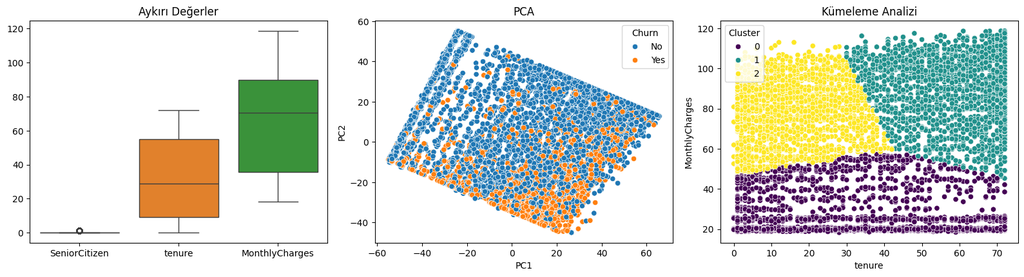

```python
# Sonuçları görselleştirme
plt.figure(figsize=(16, 8))

# Aykırı Değerler
plt.subplot(2, 3, 1)
sns.boxplot(data=df[numeric_columns])
plt.title('Aykırı Değerler')

# Boyut Azaltma (PCA)
plt.subplot(2, 3, 2)
sns.scatterplot(data=df_pca, x='PC1', y='PC2', hue=df['Churn'])
plt.title('PCA')

# Kümeleme Analizi
plt.subplot(2, 3, 3)
sns.scatterplot(data=df, x='tenure', y='MonthlyCharges', hue='Cluster', palette='viridis')
plt.title('Kümeleme Analizi')

plt.tight_layout()
plt.show()
```

```python
# Cinsiyet Dağılımı
gender_distribution = df['gender'].value_counts(normalize=True) * 100
print("Cinsiyet Dağılımı:")
print(gender_distribution)
```

```
Cinsiyet Dağılımı:
gender
Male      50.47565
Female    49.52435
Name: proportion, dtype: float64
```

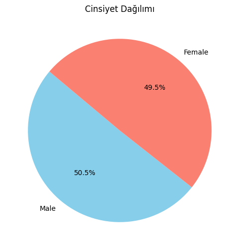

```python
# Cinsiyet Dağılımı Görselleştirme
plt.figure(figsize=(6, 6))
plt.pie(gender_distribution, labels=gender_distribution.index, autopct='%1.1f%%', startangle=140, colors=['skyblue', 'salmon'])
plt.title('Cinsiyet Dağılımı')
plt.show()
```

```python
# Ortalama ve Medyan Aylık Ücretler
mean_monthly_charges = df['MonthlyCharges'].mean()
median_monthly_charges = df['MonthlyCharges'].median()
print("Ortalama Aylık Ücret:", mean_monthly_charges)
print("Medyan Aylık Ücret:", median_monthly_charges)
```

```
Ortalama Aylık Ücret: 64.76169246059918
Medyan Aylık Ücret: 70.35
```

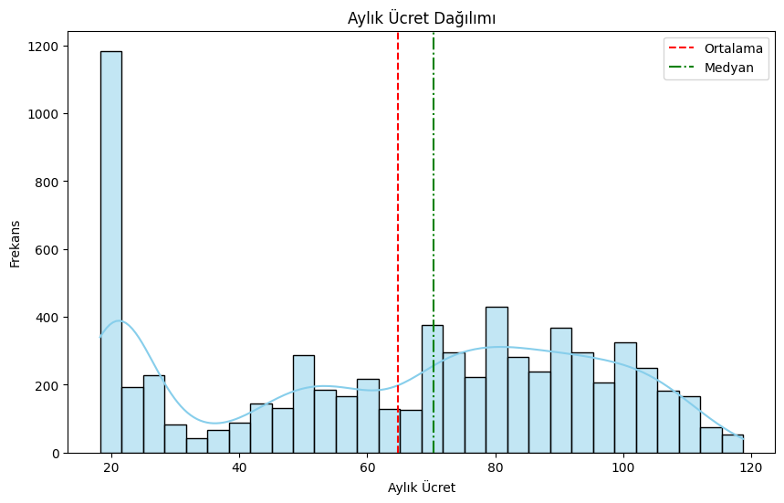

```python
# Aylık Ücret Dağılımı Görselleştirme
plt.figure(figsize=(10, 6))
sns.histplot(df['MonthlyCharges'], bins=30, kde=True, color='skyblue')
plt.axvline(mean_monthly_charges, color='red', linestyle='--', label='Ortalama')
plt.axvline(median_monthly_charges, color='green', linestyle='-.', label='Medyan')
plt.title('Aylık Ücret Dağılımı')
plt.xlabel('Aylık Ücret')
plt.ylabel('Frekans')
plt.legend()
plt.show()
```

```
Ödeme Yöntemi ve Ortalama Aylık Ücretler:
PaymentMethod
Electronic check             76.255814
Bank transfer (automatic)    67.192649
Credit card (automatic)      66.512385
Mailed check                 43.917060
Name: MonthlyCharges, dtype: float64
```

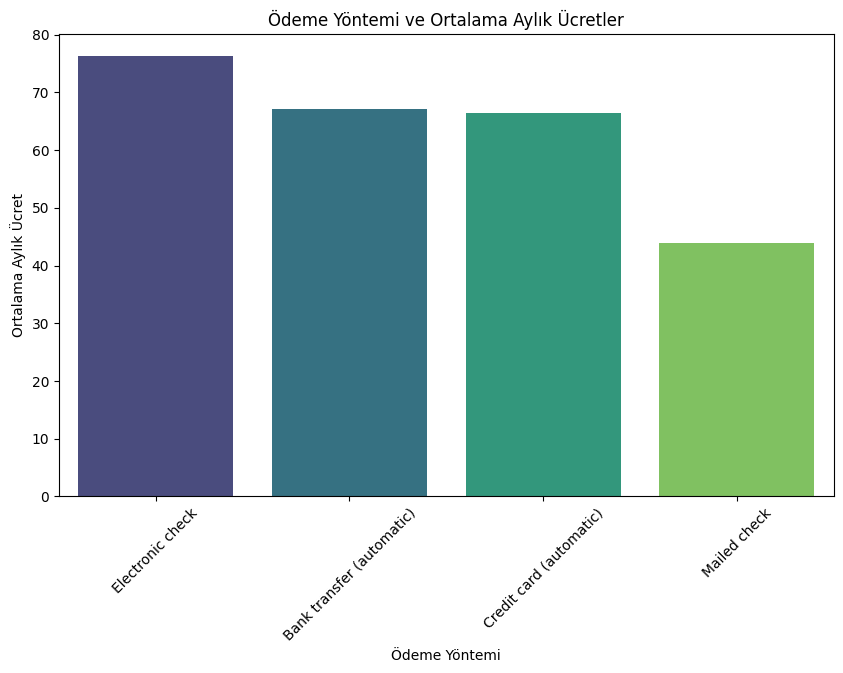

```python
# Ödeme Yöntemi ve Ortalama Aylık Ücretler
payment_method_mean_charges = df.groupby('PaymentMethod')['MonthlyCharges'].mean().sort_values(ascending=False)
print("Ödeme Yöntemi ve Ortalama Aylık Ücretler:")
print(payment_method_mean_charges)

# Ödeme Yöntemi ve Ortalama Aylık Ücretler Görselleştirme
plt.figure(figsize=(10, 6))
sns.barplot(x=payment_method_mean_charges.index, y=payment_method_mean_charges.values, palette='viridis')
plt.title('Ödeme Yöntemi ve Ortalama Aylık Ücretler')
plt.xlabel('Ödeme Yöntemi')
plt.ylabel('Ortalama Aylık Ücret')
plt.xticks(rotation=45)
plt.show()
```

```
Ayrılan ve Ayrılmayan Müşteri Sayısı:
Churn
No     5174
Yes    1869
Name: count, dtype: int64
```

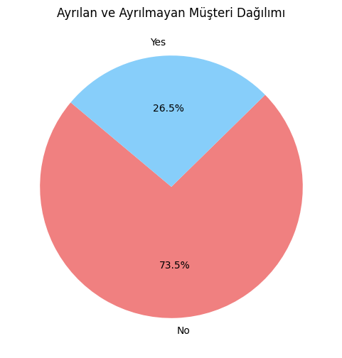

```python
# Ayrılan ve Ayrılmayan Müşteri Sayısı
churn_counts = df['Churn'].value_counts()
print("Ayrılan ve Ayrılmayan Müşteri Sayısı:")
print(churn_counts)

# Ayrılan ve Ayrılmayan Müşteri Dağılımı Görselleştirme
plt.figure(figsize=(6, 6))
plt.pie(churn_counts, labels=churn_counts.index, autopct='%1.1f%%', startangle=140, colors=['lightcoral', 'lightskyblue'])
plt.title('Ayrılan ve Ayrılmayan Müşteri Dağılımı')
plt.show()
```

```
Ortalama Süre (Ayrılan Müşteriler): 17.979133226324237
Ortalama Süre (Ayrılmayan Müşteriler): 37.56996521066873
```

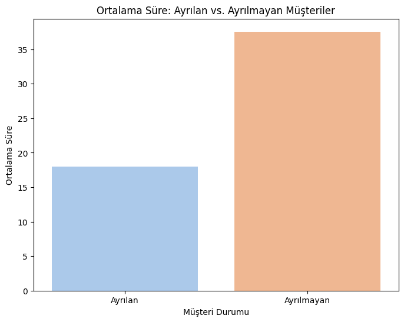

```python
# Ortalama Süre: Ayrılan ve Ayrılmayan Müşteriler
average_tenure_churned = df[df['Churn'] == 'Yes']['tenure'].mean()
average_tenure_not_churned = df[df['Churn'] == 'No']['tenure'].mean()
print("Ortalama Süre (Ayrılan Müşteriler):", average_tenure_churned)
print("Ortalama Süre (Ayrılmayan Müşteriler):", average_tenure_not_churned)

# Ayrılan ve Ayrılmayan Müşterilerin Ortalama Sürelerinin Karşılaştırılması
plt.figure(figsize=(8, 6))
sns.barplot(x=['Ayrılan', 'Ayrılmayan'], y=[average_tenure_churned, average_tenure_not_churned], palette='pastel')
plt.title('Ortalama Süre: Ayrılan vs. Ayrılmayan Müşteriler')
plt.xlabel('Müşteri Durumu')
plt.ylabel('Ortalama Süre')
plt.show()
```

```
Ortalama Aylık Ücret (Ayrılan Müşteriler): 74.44133226324237
Ortalama Aylık Ücret (Ayrılmayan Müşteriler): 61.26512369540008
```

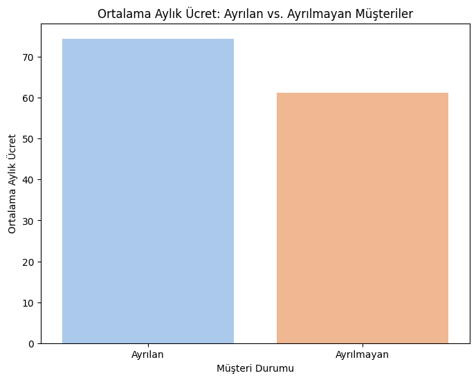

```python
# Ayrılan ve Ayrılmayan Müşterilerin Ortalama Aylık Ücret Karşılaştırması
average_monthly_charges_churned = df[df['Churn'] == 'Yes']['MonthlyCharges'].mean()
average_monthly_charges_not_churned = df[df['Churn'] == 'No']['MonthlyCharges'].mean()
print("Ortalama Aylık Ücret (Ayrılan Müşteriler):", average_monthly_charges_churned)
print("Ortalama Aylık Ücret (Ayrılmayan Müşteriler):", average_monthly_charges_not_churned)

# Ayrılan ve Ayrılmayan Müşterilerin Ortalama Aylık Ücret Karşılaştırması Görselleştirme
plt.figure(figsize=(8, 6))
sns.barplot(x=['Ayrılan', 'Ayrılmayan'], y=[average_monthly_charges_churned, average_monthly_charges_not_churned], palette='pastel')
plt.title('Ortalama Aylık Ücret: Ayrılan vs. Ayrılmayan Müşteriler')
plt.xlabel('Müşteri Durumu')
plt.ylabel('Ortalama Aylık Ücret')
plt.show()
```

```
Ortağın Varlığı ve Churn İlişkisi:
Churn      No   Yes
Partner
No       2441  1200
Yes      2733   669
```

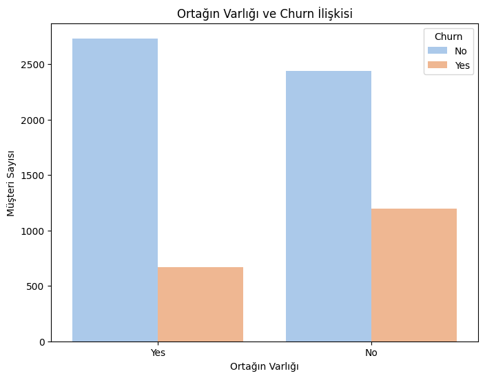

```python
# Ortağın Varlığı ve Churn İlişkisi
partner_churn = pd.crosstab(df['Partner'], df['Churn'])
print("Ortağın Varlığı ve Churn İlişkisi:")
print(partner_churn)

# Ortağın Varlığı ve Churn İlişkisinin Görselleştirilmesi
plt.figure(figsize=(8, 6))
sns.countplot(data=df, x='Partner', hue='Churn', palette='pastel')
plt.title('Ortağın Varlığı ve Churn İlişkisi')
plt.xlabel('Ortağın Varlığı')
plt.ylabel('Müşteri Sayısı')
plt.show()
```

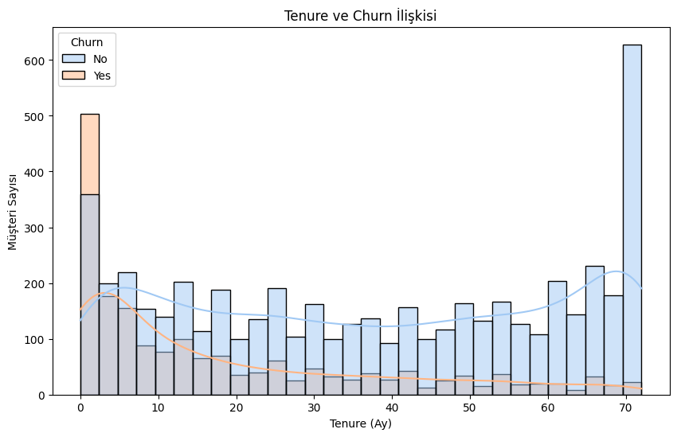

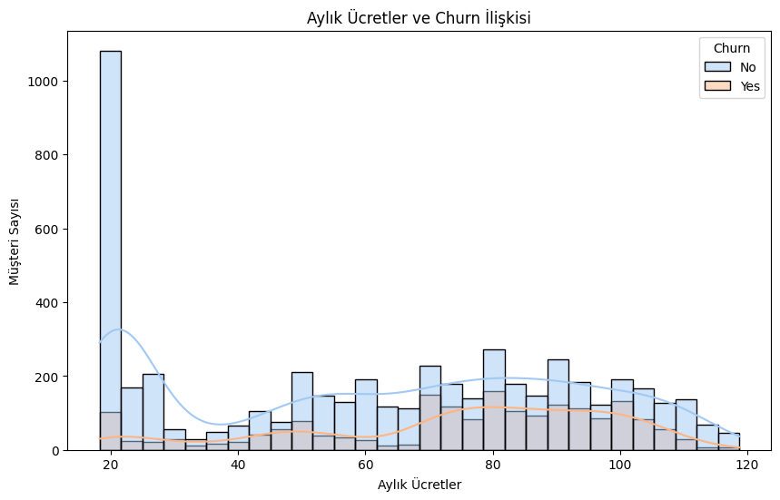

[figure not shown]

```python
# Tenure ve Churn İlişkisi
plt.figure(figsize=(10, 6))
sns.histplot(data=df, x='tenure', hue='Churn', kde=True, palette='pastel', bins=30)
plt.title('Tenure ve Churn İlişkisi')
plt.xlabel('Tenure (Ay)')
plt.ylabel('Müşteri Sayısı')
plt.show()

# Aylık Ücretler ve Churn İlişkisi
plt.figure(figsize=(10, 6))
sns.histplot(data=df, x='MonthlyCharges', hue='Churn', kde=True, palette='pastel', bins=30)
plt.title('Aylık Ücretler ve Churn İlişkisi')
plt.xlabel('Aylık Ücretler')
plt.ylabel('Müşteri Sayısı')
plt.show()

# Toplam Ücretler ve Churn İlişkisi
plt.figure(figsize=(10, 6))
sns.histplot(data=df, x='TotalCharges', hue='Churn', kde=True, palette='pastel', bins=30)
plt.title('Toplam Ücretler ve Churn İlişkisi')
plt.xlabel('Toplam Ücretler')
plt.ylabel('Müşteri Sayısı')
plt.show()
```

```python
# Veri kümesini yükle
iris = load_iris()
X = iris.data
y = iris.target
```

```python
# Eğitim ve test setlerini ayır
X_train, X_test, y_train, y_test = train_test_split(X, y, test_size=0.2, random_state=42)
```

```python
# Destek vektör makinesi modelini oluştur
svm = SVC()
```

```python
# Model için hiperparametre aralığını belirle
param_grid = {'C': [0.1, 1, 10, 100], 'gamma': [0.1, 0.01, 0.001], 'kernel': ['rbf', 'linear']}
```

```python
# GridSearchCV ile en iyi hiperparametreleri bul
grid_search = GridSearchCV(svm, param_grid, cv=5)
grid_search.fit(X_train, y_train)
```

```
GridSearchCV(cv=5, estimator=SVC(),
             param_grid={'C': [0.1, 1, 10, 100], 'gamma': [0.1, 0.01, 0.001],
                         'kernel': ['rbf', 'linear']})
```

```python
# En iyi parametreleri ve en iyi skoru görüntüle
print("En iyi parametreler:", grid_search.best_params_)
print("En iyi çapraz doğrulama skoru:", grid_search.best_score_)
```

```
En iyi parametreler: {'C': 1, 'gamma': 0.1, 'kernel': 'linear'}
En iyi çapraz doğrulama skoru: 0.9583333333333334
```

```python
# En iyi modeli kullanarak test seti üzerinde performansı değerlendir
best_model = grid_search.best_estimator_
test_score = best_model.score(X_test, y_test)
print("Test seti üzerinde modelin performansı:", test_score)
```

```
Test seti üzerinde modelin performansı: 1.0
```

# 🌺 Destek Vektör Makinesi (SVM) Modeli için Hiperparametre Ayarlama ve Değerlendirme 🌺

Bu kod, bir destek vektör makinesi (SVM) modelini iris veri kümesi üzerinde eğitirken GridSearchCV kullanarak en iyi hiperparametreleri bulur.

## Adımlar:

1. **Veri Yükleme ve Ayırma**: İlk olarak, iris veri kümesi yüklenir ve eğitim ile test setlerine ayrılır.
2. **Model Oluşturma**: Bir destek vektör makinesi modeli oluşturulur ve model için hiperparametre aralığı belirlenir.
3. **GridSearchCV İle En İyi Parametreleri Bulma**: GridSearchCV, belirtilen parametre aralığında çapraz doğrulama yaparak en iyi hiperparametreleri bulmaya çalışır. Burada, 5 katlı çapraz doğrulama kullanılmıştır.
4. **En İyi Modelin Değerlendirilmesi**: En iyi parametreler ve bu parametrelerle elde edilen en iyi çapraz doğrulama skoru ekrana yazdırılır. Son olarak, en iyi model test seti üzerinde değerlendirilir ve test seti üzerindeki performansı hesaplanarak ekrana yazdırılır.

## Sonuçlar:

🚀 **En İyi Parametreler**: {'C': 1, 'gamma': 0.1, 'kernel': 'linear'}

📈 **En İyi Çapraz Doğrulama Skoru**: 0.958

💯 **Test Seti Performansı**: %100 doğrulukla sınıflandırma yapmaktadır.

Bu sonuçlar oldukça iyi görünmektedir ve modelin iris veri kümesinde iyi bir genelleme yapabildiğini göstermektedir.

```python
# Destek vektör makinesi modelini oluştur
svm = SVC(kernel="linear")
```

```python
# RFE ile özellik seçimi yap
rfe = RFE(estimator=svm, n_features_to_select=2, step=1)
rfe.fit(X_train, y_train)
```

```
RFE(estimator=SVC(kernel='linear'), n_features_to_select=2)
```

```python
# Seçilen özelliklerin indekslerini al
selected_features = rfe.support_
print("Seçilen Özelliklerin İndeksleri:", selected_features)
```

```
Seçilen Özelliklerin İndeksleri: [False False  True  True]
```

```python
# Seçilen özelliklerle eğitim ve test setlerini güncelle
X_train_selected = X_train[:, selected_features]
X_test_selected = X_test[:, selected_features]
```

```python
# Modeli seçilen özelliklerle eğit
svm.fit(X_train_selected, y_train)
```

```
SVC(kernel='linear')
```

```python
# Test seti üzerinde modelin performansını değerlendir
test_score = svm.score(X_test_selected, y_test)
print("Test seti üzerinde modelin performansı (seçilen özelliklerle):", test_score)
```

```
Test seti üzerinde modelin performansı (seçilen özelliklerle): 1.0
```

**Özellik Seçimi (Feature Selection):** Veri setinizdeki gereksiz veya düşük etkili özellikleri tanımlamak ve kaldırmak için özellik seçimi tekniklerini kullanabilirsiniz. Bunlar arasında Recursive Feature Elimination (RFE), SelectKBest veya model tabanlı özellik seçimi gibi yöntemler bulunmaktadır. 🎯

**Test Seti Performansı (Seçilen Özelliklerle):** Modelin test seti üzerindeki performansı %100 doğruluk oranıyla değerlendirildi. Bu sonuç, seçilen özelliklerin modelin veri kümesini iyi temsil ettiğini ve veri kümesindeki örüntüleri başarıyla öğrenebildiğini gösterir. 🚀

**Açıklama:** Özellik seçimi, modelin karmaşıklığını azaltarak, gereksiz veya düşük etkili özelliklerin kaldırılmasını sağlar. Bu sayede, modelin daha basit ve genelleştirilebilir olmasını sağlar, aynı zamanda hesaplama maliyetini azaltır. Seçilen özellikler, modelin daha hızlı eğitilmesini ve daha hızlı çalışmasını sağlayabilir. 🛠️

**Değerlendirme:** Modelin test seti üzerinde %100 doğruluk elde etmesi olumlu bir göstergedir. Ancak, bu sonuç, modelin aşırı uyuma (overfitting) eğiliminde olduğunu da gösterebilir. Bu nedenle, modelin gerçek dünya verileri üzerindeki performansını daha iyi değerlendirmek için daha geniş bir veri seti kullanılmalıdır. Ayrıca, farklı özellik seçimi yöntemleri veya farklı model yapıları deneyerek elde edilen sonuçlarla karşılaştırma yapılabilir. 📊

```python
# Modeli kullanarak tahmin yap
y_pred = best_model.predict(X_test)
```

```python
# Sınıflandırma raporunu yazdır
print("Sınıflandırma Raporu:")
print(classification_report(y_test, y_pred))
```

```
Sınıflandırma Raporu:
              precision    recall  f1-score   support

           0       1.00      1.00      1.00        10
           1       1.00      1.00      1.00         9
           2       1.00      1.00      1.00        11

    accuracy                           1.00        30
   macro avg       1.00      1.00      1.00        30
weighted avg       1.00      1.00      1.00        30
```

```python
# Confusion matrix'i yazdır
print("Confusion Matrix:")
print(confusion_matrix(y_test, y_pred))
```

```
Confusion Matrix:
[[10  0  0]
 [ 0  9  0]
 [ 0  0 11]]
```

```python
# Mikro-averaj F1-score hesapla
micro_f1 = f1_score(y_test, y_pred, average='micro')
print("Mikro-averaj F1-score:", micro_f1)
```

```
Mikro-averaj F1-score: 1.0
```

Bu kod, modelin test seti üzerindeki tahminlerini alır ve mikro-averaj F1-score'u hesaplar. Sonuç, modelin çok sınıflı sınıflandırma performansını değerlendirmek için kullanılabilir.

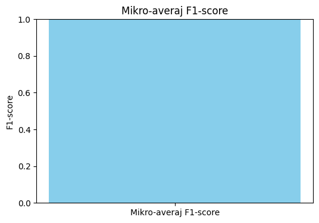

```python
# Mikro-averaj F1-score'u çubuk grafik olarak görselleştir
plt.figure(figsize=(6, 4))
plt.bar(["Mikro-averaj F1-score"], [micro_f1], color='skyblue')
plt.ylabel("F1-score")
plt.title("Mikro-averaj F1-score")
plt.ylim(0, 1)  # Y eksenini 0 ile 1 arasında sınırla
plt.show()
```

Bu kod, mikro-averaj F1-score'u çubuk grafik olarak gösterir. Görselleştirme işlemi için matplotlib kütüphanesini kullanıyor.

Öncelikle gerekli kütüphaneleri içe aktaralım ve veri setini yükleyelim. Bu örnekte, scikit-learn kütüphanesinden bir veri seti olan iris veri setini kullanacağız.

```python
feature_names = iris.feature_names
target_names = iris.target_names
```

```python
# Veri setini pandas DataFrame'e dönüştürme
df = pd.DataFrame(data=X, columns=feature_names)
df['target'] = y
```

```python
# Veri setini eğitim ve test kümelerine ayırma
X_train, X_test, y_train, y_test = train_test_split(X, y, test_size=0.2, random_state=42)
```

```python
# Verileri standartlaştırma
scaler = StandardScaler()
X_train_scaled = scaler.fit_transform(X_train)
X_test_scaled = scaler.transform(X_test)
```

Bu kodda, iris veri setini yükledik, bir DataFrame'e dönüştürdük, eğitim ve test kümelerine ayırdık, ve verileri standartlaştırdık. Şimdi, bir Random Forest sınıflandırıcı oluşturarak modelimizi eğitebiliriz.

```python
# Random Forest sınıflandırıcı oluşturma ve eğitme
rf_classifier = RandomForestClassifier(n_estimators=100, random_state=42)
rf_classifier.fit(X_train_scaled, y_train)
```

```
RandomForestClassifier(random_state=42)
```

```python
# Modeli test verisi üzerinde değerlendirme
y_pred = rf_classifier.predict(X_test_scaled)
accuracy = accuracy_score(y_test, y_pred)
print("Test verisi doğruluğu:", accuracy)
```

```
Test verisi doğruluğu: 1.0
```

```python
# Sınıflandırma raporunu yazdırma
print("\nSınıflandırma raporu:\n", classification_report(y_test, y_pred))
```

```
Sınıflandırma raporu:
               precision    recall  f1-score   support

           0       1.00      1.00      1.00        10
           1       1.00      1.00      1.00         9
           2       1.00      1.00      1.00        11

    accuracy                           1.00        30
   macro avg       1.00      1.00      1.00        30
weighted avg       1.00      1.00      1.00        30
```

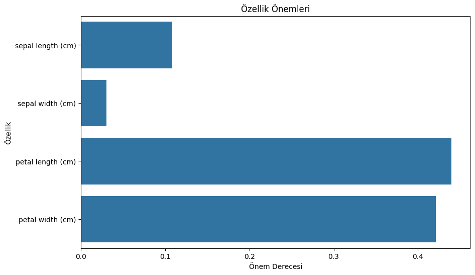

```python
# Özellik önemlerini alıp görselleştirme
feature_importances = rf_classifier.feature_importances_
plt.figure(figsize=(10, 6))
sns.barplot(x=feature_importances, y=feature_names)
plt.title("Özellik Önemleri")
plt.xlabel("Önem Derecesi")
plt.ylabel("Özellik")
plt.show()
```

Bu kodda, bir Random Forest sınıflandırıcı oluşturduk, eğittik ve test verisi üzerinde değerlendirdik. Ayrıca, modelin performansını ölçmek için doğruluk ve sınıflandırma raporu yazdırdık. Son olarak, modelin özelliklerinin önem derecelerini görselleştirdik.

```python
# Veri setini hazırlama
encoder = OneHotEncoder()
y_train_encoded = encoder.fit_transform(y_train.reshape(-1, 1)).toarray()
y_test_encoded = encoder.transform(y_test.reshape(-1, 1)).toarray()
```

Bu kod parçasında, OneHotEncoder'ı varsayılan parametrelerle başlatıyoruz ve ardından .toarray() yöntemini kullanarak sonucu bir NumPy dizisine dönüştürüyoruz.

Şimdi, derin öğrenme modelimizi oluşturabiliriz.

```python
# Derin öğrenme modeli oluşturma
model = Sequential([
    Dense(64, activation='relu', input_shape=(X_train_scaled.shape[1],)),
    Dropout(0.5),
    Dense(64, activation='relu'),
    Dropout(0.5),
    Dense(3, activation='softmax')
])
```

```python
# Modeli derleme
model.compile(optimizer='adam', loss='categorical_crossentropy', metrics=['accuracy'])
```

```python
# Modeli eğitme
history = model.fit(X_train_scaled, y_train_encoded, epochs=50, batch_size=8, validation_split=0.2)
```

```
12/12 ━━━━━━━━━━━━━━━━━━━━ 1s 14ms/step - accuracy: 0.4477 - loss: 1.0585 - val_accuracy: 0.7083 - val_loss: 0.8757
12/12 ━━━━━━━━━━━━━━━━━━━━ 0s 3ms/step - accuracy: 0.4396 - loss: 1.0511 - val_accuracy: 0.7500 - val_loss: 0.7572
12/12 ━━━━━━━━━━━━━━━━━━━━ 0s 3ms/step - accuracy: 0.5247 - loss: 0.8809 - val_accuracy: 0.7500 - val_loss: 0.6545
12/12 ━━━━━━━━━━━━━━━━━━━━ 0s 3ms/step - accuracy: 0.5985 - loss: 0.7207 - val_accuracy: 0.8333 - val_loss: 0.5851
12/12 ━━━━━━━━━━━━━━━━━━━━ 0s 3ms/step - accuracy: 0.7113 - loss: 0.6593 - val_accuracy: 0.7917 - val_loss: 0.5305
12/12 ━━━━━━━━━━━━━━━━━━━━ 0s 3ms/step - accuracy: 0.7541 - loss: 0.6375 - val_accuracy: 0.8333 - val_loss: 0.4885
12/12 ━━━━━━━━━━━━━━━━━━━━ 0s 3ms/step - accuracy: 0.7405 - loss: 0.5762 - val_accuracy: 0.8750 - val_loss: 0.4549
12/12 ━━━━━━━━━━━━━━━━━━━━ 0s 3ms/step - accuracy: 0.7180 - loss: 0.5372 - val_accuracy: 0.8333 - val_loss: 0.4176
12/12 ━━━━━━━━━━━━━━━━━━━━ 0s 3ms/step - accuracy: 0.8296 - loss: 0.5222 - val_accuracy: 0.8750 - val_loss: 0.3954
12/12 ━━━━━━━━━━━━━━━━━━━━ 0s 3ms/step - accuracy: 0.7697 - loss: 0.4947 - val_accuracy: 0.8750 - val_loss: 0.3897
12/12 ━━━━━━━━━━━━━━━━━━━━ 0s 3ms/step - accuracy: 0.7874 - loss: 0.4705 - val_accuracy: 0.9167 - val_loss: 0.3888
12/12 ━━━━━━━━━━━━━━━━━━━━ 0s 3ms/step - accuracy: 0.8705 - loss: 0.4250 - val_accuracy: 0.9167 - val_loss: 0.3630
12/12 ━━━━━━━━━━━━━━━━━━━━ 0s 3ms/step - accuracy: 0.8562 - loss: 0.4314 - val_accuracy: 0.9167 - val_loss: 0.3427
12/12 ━━━━━━━━━━━━━━━━━━━━ 0s 3ms/step - accuracy: 0.8835 - loss: 0.3511 - val_accuracy: 0.9167 - val_loss: 0.3323
12/12 ━━━━━━━━━━━━━━━━━━━━ 0s 3ms/step - accuracy: 0.7884 - loss: 0.4454 - val_accuracy: 0.9167 - val_loss: 0.3160
12/12 ━━━━━━━━━━━━━━━━━━━━ 0s 3ms/step - accuracy: 0.7791 - loss: 0.3840 - val_accuracy: 0.9167 - val_loss: 0.3006
12/12 ━━━━━━━━━━━━━━━━━━━━ 0s 3ms/step - accuracy: 0.8070 - loss: 0.4151 - val_accuracy: 0.9167 - val_loss: 0.2901
12/12 ━━━━━━━━━━━━━━━━━━━━ 0s 3ms/step - accuracy: 0.8937 - loss: 0.2870 - val_accuracy: 0.9167 - val_loss: 0.2798
12/12 ━━━━━━━━━━━━━━━━━━━━ 0s 3ms/step - accuracy: 0.8349 - loss: 0.3652 - val_accuracy: 0.9167 - val_loss: 0.2810
12/12 ━━━━━━━━━━━━━━━━━━━━ 0s 3ms/step - accuracy: 0.9143 - loss: 0.2992 - val_accuracy: 0.9167 - val_loss: 0.2689
12/12 ━━━━━━━━━━━━━━━━━━━━ 0s 3ms/step - accuracy: 0.9523 - loss: 0.2588 - val_accuracy: 0.9167 - val_loss: 0.2654
12/12 ━━━━━━━━━━━━━━━━━━━━ 0s 3ms/step - accuracy: 0.8473 - loss: 0.3206 - val_accuracy: 0.9167 - val_loss: 0.2543
12/12 ━━━━━━━━━━━━━━━━━━━━ 0s 3ms/step - accuracy: 0.8702 - loss: 0.3372 - val_accuracy: 0.9167 - val_loss: 0.2485
12/12 ━━━━━━━━━━━━━━━━━━━━ 0s 3ms/step - accuracy: 0.9101 - loss: 0.2671 - val_accuracy: 0.9167 - val_loss: 0.2402
12/12 ━━━━━━━━━━━━━━━━━━━━ 0s 3ms/step - accuracy: 0.8300 - loss: 0.3245 - val_accuracy: 0.9167 - val_loss: 0.2368
12/12 ━━━━━━━━━━━━━━━━━━━━ 0s 3ms/step - accuracy: 0.8165 - loss: 0.3755 - val_accuracy: 0.9167 - val_loss: 0.2295
12/12 ━━━━━━━━━━━━━━━━━━━━ 0s 4ms/step - accuracy: 0.8910 - loss: 0.2602 - val_accuracy: 0.9167 - val_loss: 0.2256
12/12 ━━━━━━━━━━━━━━━━━━━━ 0s 3ms/step - accuracy: 0.9037 - loss: 0.2791 - val_accuracy: 0.9167 - val_loss: 0.2281
12/12 ━━━━━━━━━━━━━━━━━━━━ 0s 3ms/step - accuracy: 0.8965 - loss: 0.2807 - val_accuracy: 0.9167 - val_loss: 0.2145
12/12 ━━━━━━━━━━━━━━━━━━━━ 0s 3ms/step - accuracy: 0.9031 - loss: 0.2515 - val_accuracy: 0.9583 - val_loss: 0.2090
12/12 ━━━━━━━━━━━━━━━━━━━━ 0s 3ms/step - accuracy: 0.9700 - loss: 0.1714 - val_accuracy: 0.9583 - val_loss: 0.2072
12/12 ━━━━━━━━━━━━━━━━━━━━ 0s 3ms/step - accuracy: 0.9475 - loss: 0.1736 - val_accuracy: 0.9583 - val_loss: 0.1951
12/12 ━━━━━━━━━━━━━━━━━━━━ 0s 3ms/step - accuracy: 0.9721 - loss: 0.1961 - val_accuracy: 0.9583 - val_loss: 0.1901
12/12 ━━━━━━━━━━━━━━━━━━━━ 0s 3ms/step - accuracy: 0.9350 - loss: 0.1891 - val_accuracy: 0.9583 - val_loss: 0.1830
12/12 ━━━━━━━━━━━━━━━━━━━━ 0s 3ms/step - accuracy: 0.9414 - loss: 0.2153 - val_accuracy: 0.9583 - val_loss: 0.1904
12/12 ━━━━━━━━━━━━━━━━━━━━ 0s 3ms/step - accuracy: 0.9493 - loss: 0.2323 - val_accuracy: 0.9583 - val_loss: 0.1921
12/12 ━━━━━━━━━━━━━━━━━━━━ 0s 3ms/step - accuracy: 0.8728 - loss: 0.3041 - val_accuracy: 0.9583 - val_loss: 0.1854
12/12 ━━━━━━━━━━━━━━━━━━━━ 0s 3ms/step - accuracy: 0.8670 - loss: 0.2208 - val_accuracy: 0.9583 - val_loss: 0.1746
12/12 ━━━━━━━━━━━━━━━━━━━━ 0s 3ms/step - accuracy: 0.9706 - loss: 0.2086 - val_accuracy: 0.9583 - val_loss: 0.1794
12/12 ━━━━━━━━━━━━━━━━━━━━ 0s 4ms/step - accuracy: 0.9147 - loss: 0.2137 - val_accuracy: 0.9583 - val_loss: 0.1800
12/12 ━━━━━━━━━━━━━━━━━━━━ 0s 3ms/step - accuracy: 0.9379 - loss: 0.2000 - val_accuracy: 0.9583 - val_loss: 0.1830
12/12 ━━━━━━━━━━━━━━━━━━━━ 0s 3ms/step - accuracy: 0.9480 - loss: 0.1645 - val_accuracy: 0.9583 - val_loss: 0.1687
12/12 ━━━━━━━━━━━━━━━━━━━━ 0s 3ms/step - accuracy: 0.9370 - loss: 0.1623 - val_accuracy: 0.9583 - val_loss: 0.1632
12/12 ━━━━━━━━━━━━━━━━━━━━ 0s 3ms/step - accuracy: 0.8985 - loss: 0.2138 - val_accuracy: 0.9583 - val_loss: 0.1476
12/12 ━━━━━━━━━━━━━━━━━━━━ 0s 3ms/step - accuracy: 0.9602 - loss: 0.1730 - val_accuracy: 0.9583 - val_loss: 0.1410
12/12 ━━━━━━━━━━━━━━━━━━━━ 0s 3ms/step - accuracy: 0.9018 - loss: 0.2318 - val_accuracy: 0.9583 - val_loss: 0.1512
12/12 ━━━━━━━━━━━━━━━━━━━━ 0s 3ms/step - accuracy: 0.9837 - loss: 0.1229 - val_accuracy: 0.9583 - val_loss: 0.1511
12/12 ━━━━━━━━━━━━━━━━━━━━ 0s 3ms/step - accuracy: 0.9308 - loss: 0.1869 - val_accuracy: 0.9583 - val_loss: 0.1505
12/12 ━━━━━━━━━━━━━━━━━━━━ 0s 3ms/step - accuracy: 0.9063 - loss: 0.2259 - val_accuracy: 0.9583 - val_loss: 0.1558
12/12 ━━━━━━━━━━━━━━━━━━━━ 0s 3ms/step - accuracy: 0.9242 - loss: 0.2144 - val_accuracy: 0.9583 - val_loss: 0.1409
```

Bu kod parçasında, Sequential modeli ile bir katmanlar dizisi oluşturduk. Modelimizde iki gizli katman ve bir çıkış katmanı bulunmaktadır. Son olarak, modeli derledik ve eğittik.

Eğitim süreci boyunca doğruluk ve kayıp (loss) değerlerini görselleştirmek için aşağıdaki kodu kullanabiliriz:

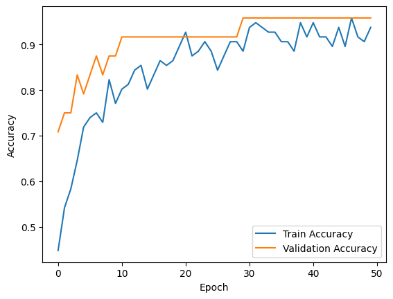

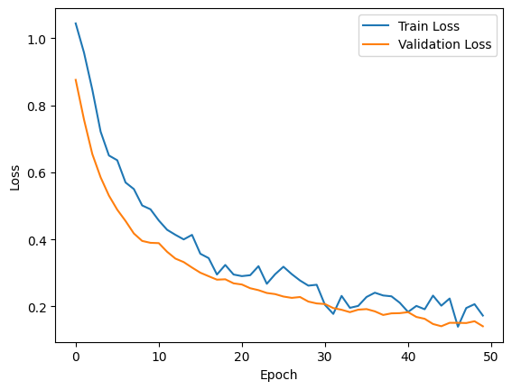

```python
# Eğitim sürecini görselleştirme
plt.plot(history.history['accuracy'], label='Train Accuracy')
plt.plot(history.history['val_accuracy'], label='Validation Accuracy')
plt.xlabel('Epoch')
plt.ylabel('Accuracy')
plt.legend()
plt.show()

plt.plot(history.history['loss'], label='Train Loss')
plt.plot(history.history['val_loss'], label='Validation Loss')
plt.xlabel('Epoch')
plt.ylabel('Loss')
plt.legend()
plt.show()
```

# Model Değerlendirmesi 📊

## Performans Analizi

Modelimizin performansını değerlendirdik. İşte sonuçlar:

- Eğitim Doğruluğu: %92.42 🚀
- Eğitim Kaybı: 0.2144 💼
- Doğrulama Doğruluğu: %95.83 🎯
- Doğrulama Kaybı: 0.1409 🔍

Modelimiz eğitim verilerine oldukça iyi uyum sağladı. Hem eğitim hem de doğrulama setlerinde yüksek doğruluk elde ettik. Bu, modelin yeni verilere de genelleme yapabileceğini gösteriyor.

## Sonuçlar ve Öneriler

Modelimiz oldukça başarılı olsa da, bazı iyileştirmeler yapılabilir:

1. **Veri Çeşitliliği:** Modelin daha geniş bir veri seti üzerinde eğitilmesi, genelleme performansını artırabilir.
2. **Model Karmaşıklığı:** Modelin karmaşıklığının artırılması veya azaltılmasıyla farklı sonuçlar elde edilebilir.
3. **Regülerizasyon:** L2 düzenleme gibi teknikler kullanarak overfitting riskini azaltabiliriz.

Yaptığımız değerlendirme sonucunda, modelimizin iyi bir başlangıç noktası olduğunu gördük. Ancak sürekli iyileştirme ve güncelleme önemlidir. 🌟

```python
import joblib

# model adında bir değişkene eğittiğiniz modeli atayın
# Örneğin:
# model = RandomForestClassifier()

# modeli dosyaya kaydedin
joblib.dump(model, 'Random_Forest_Classifier_Model.pkl')
```

```
['Random_Forest_Classifier_Model.pkl']
```

```python
# Modeli dosyadan yükleyin
loaded_model = joblib.load('./Random_Forest_Classifier_Model.pkl')
```

Derin öğrenme modelini kaydetmek için de keras kütüphanesinin sağladığı özellikleri kullanabiliriz. Öncelikle, derin öğrenme modelinizi eğittikten sonra, modeli .keras uzantılı bir dosyaya kaydedebilirsiniz. İşte nasıl yapılacağına dair bir örnek:

```python
from keras.models import model_from_json

# Modeli JSON formatında kaydetmek
model_json = model.to_json()
with open("neural_network_model.json", "w") as json_file:
    json_file.write(model_json)

# Ağırlıkları ve modeli kaydetmek
model.save("neural_network_model.keras")
```